# team

Sonia Thomas

2/5/2020

## Team Questions

```r
choco <- read.csv("https://xdaiisu.github.io/ds202materials/hwlabs/choco.csv")
str(choco)
```

```
## 'data.frame':    1852 obs. of  9 variables:
##  $ Company             : Factor w/ 431 levels "A. Morin","Acalli",..: 1 1 1 1 1 1 1 1 1 1 ...
##  $ Specific.Bean.Origin: Factor w/ 1067 levels "\"heirloom\", Arriba Nacional",..: 15 504 752 578 138 366 251 119 760 217 ...
##  $ REF                 : int  1876 1676 1011 1011 1011 1011 1015 1015 1015 1015 ...
##  $ Review.Date         : int  2016 2015 2013 2013 2013 2013 2013 2013 2013 2013 ...
##  $ Cocoa.Pct           : num  63 70 70 70 70 70 70 70 70 70 ...
##  $ Company.Location    : Factor w/ 61 levels "Amsterdam","Argentina",..: 19 19 19 19 19 19 19 19 19 19 ...
##  $ Rating              : num  3.75 2.75 2.75 3 3.25 3.75 2.75 3 3.25 4 ...
##  $ Bean.Type           : Factor w/ 41 levels "","Amazon","Amazon mix",..: 1 1 1 9 1 1 1 1 1 34 ...
##  $ Broad.Bean.Origin   : Factor w/ 100 levels "","Africa, Carribean, C. Am.",..: 69 79 54 47 6 23 12 7 55 92 ...
```

```r
nrow(choco)
```

```
## [1] 1852
```

**Question 1:** 1,852 chocolate bars were rated.

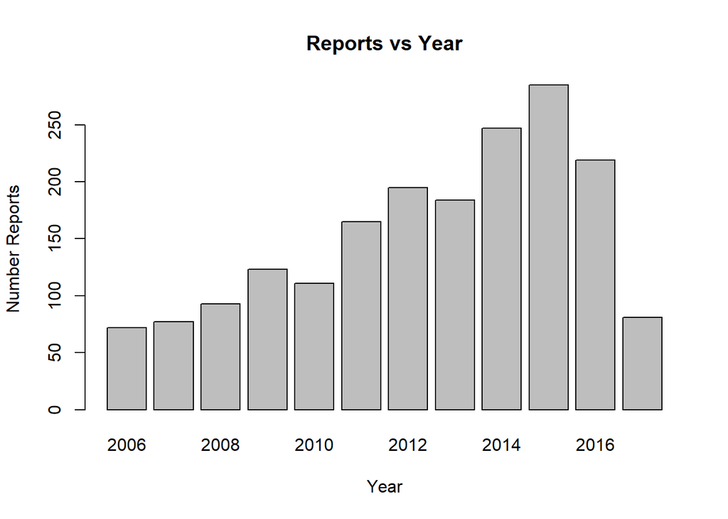

```r
barplot(table(choco$Review.Date), main = 'Reports vs Year', xlab = "Year", ylab = 'Number Reports')
```

**Question 2:** The number of ratings gradually increases per year up until 2015 and then in 2016-2017 it drops back down. Specifically in 2017 it drops back down to the same number of ratings it was in 2006.

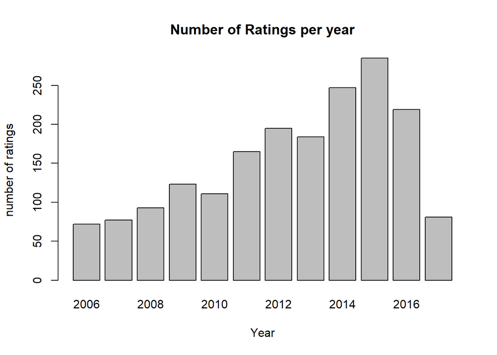

```r
barplot(table(choco$Review.Date), xlab = 'Year', ylab ='number of ratings', main = 'Number of Ratings per year')
```

```r
sort(table(choco$Company.Location), decreasing = TRUE)[1:3]
```

```
##
## U.S.A. France Canada
##    787    158    132
```

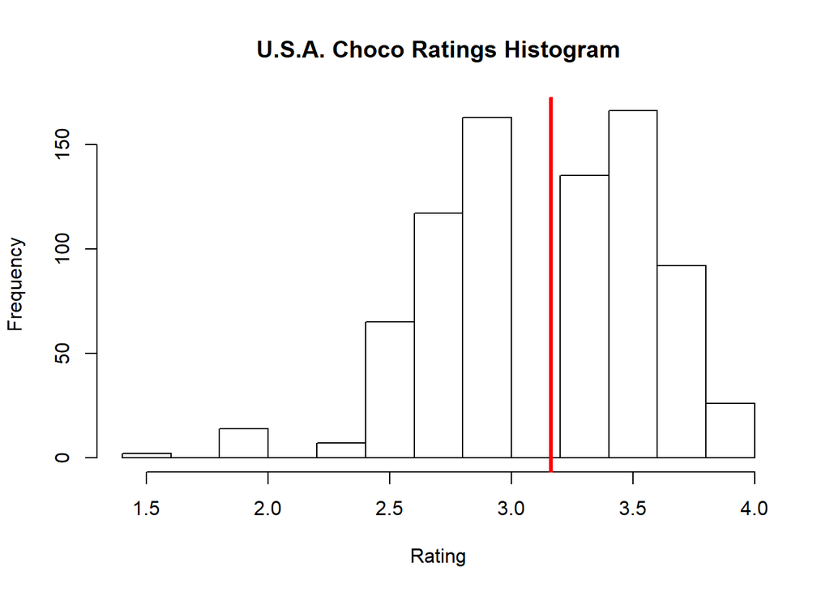

```r
USA = subset(choco, choco$Company.Location == 'U.S.A.')
hist(USA$Rating, main = 'U.S.A. Choco Ratings Histogram', ylab= 'Frequency', xlab = 'Rating')
abline(v=mean(USA$Rating), lwd = 3, col="red")
```

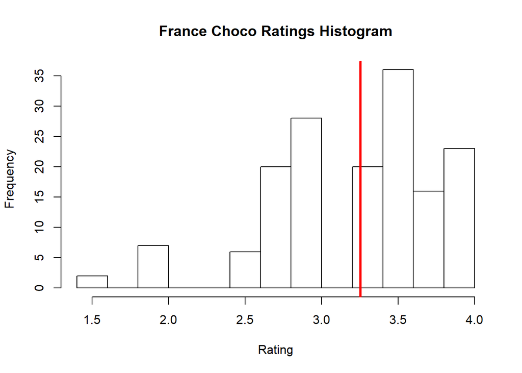

```r
France = subset(choco, choco$Company.Location == 'France')
hist(France$Rating, main = 'France Choco Ratings Histogram', ylab= 'Frequency', xlab = 'Rating')
abline(v=mean(France$Rating), lwd = 3, col="red")
```

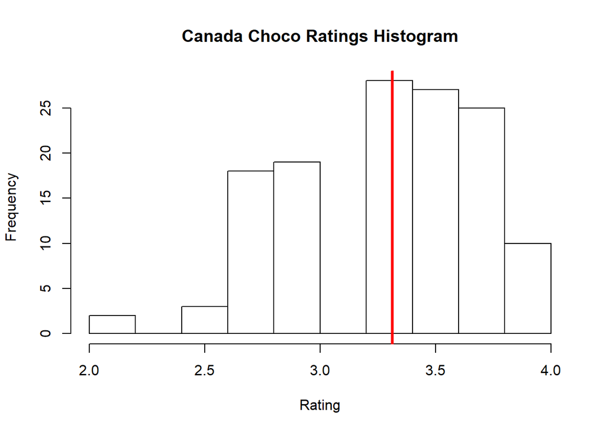

```r
Canada = subset(choco, choco$Company.Location == 'Canada')
hist(Canada$Rating, main = 'Canada Choco Ratings Histogram', ylab= 'Frequency', xlab = 'Rating')
abline(v=mean(Canada$Rating), lwd = 3, col="red")
```

**Question 4:** Our question is as follows: How many different (unique) bean types have been rated?

**Question 5:** By using the “unique” funcion in R, we found that there are 41 different types of beans that were rated in this dataset.

```r
numBeanType = length(unique(choco$Bean.Type))
numBeanType
```

```
## [1] 41
```

**Question 6:**

1. Sonia wrote individual1.Rmd file, and John wrote individual2.Rmd file.
2. Sonia created a repository called ds202_lab2, and gave John access to contribute to it.
3. Sonia pushed her individual1.Rmd and individual1.html files to the repo.
4. John cloned Sonia’s repo onto his local computer.
5. John pushed his individual2.Rmd and individual2.html files to the repo.
6. Sonia started writing the team.Rmd file, but at the end of Wednesday’s class we were unable to push the incomplete team.Rmd file to the repo. This was due to conflicting branches that we were able to clear up on Monday.
7. On Monday, Sonia finished questions 1 and 2 for the team.Rmd file, and pushed it to the repo.
8. John pulled the team.Rmd file from the repo, and finished the final questions.
9. John is about to push the team.Rmd and team.html files to the repo.